# Exploratorios 2024

Author

Karen Velásquez-C

Published

October 5, 2024

## Introducción a exploratorios

Para esta clase emplearemos la paquetería `lterdatasampler` la cual tiene como objetivo proporcionar subconjuntos de datos medioambientales útiles para la enseñanza y la formación en ciencia de datos.

### Instalación paquetería

Podemos instalar la paquetería desde CRAN o la versión en desarrollo en GitHub

```r
#install.packages("lterdatasampler", repos = "http://cran.us.r-project.org")
#remotes::install_github("lter/lterdatasampler")
```

[figure not shown]

## Relaciones Univariadas

Emplearemos los datos del cangrejo violinista (*Minuca pugnax*) en marismas de Florida a Massachusetts durante el verano de 2016 en la isla Plum.

```r
library(lterdatasampler)
library(tidyverse)
library(ggrepel)
library(ggridges)
library(patchwork)
```

Primero exploraremos la tabla de datos, y observaremos las medias, mínimos, máximos….

```r
crab <- pie_crab %>% select(where(is.numeric))
summary(crab)
```

```
    latitude          size          air_temp      air_temp_sd
 Min.   :30.00   Min.   : 6.64   Min.   :10.29   Min.   :6.391
 1st Qu.:34.00   1st Qu.:12.02   1st Qu.:12.05   1st Qu.:8.110
 Median :39.10   Median :14.44   Median :13.93   Median :8.410
 Mean   :37.69   Mean   :14.66   Mean   :15.20   Mean   :8.654
 3rd Qu.:41.60   3rd Qu.:17.34   3rd Qu.:18.63   3rd Qu.:9.483
 Max.   :42.70   Max.   :23.43   Max.   :21.79   Max.   :9.965
   water_temp    water_temp_sd
 Min.   :13.98   Min.   :4.838
 1st Qu.:14.33   1st Qu.:6.567
 Median :17.50   Median :6.998
 Mean   :17.65   Mean   :7.252
 3rd Qu.:20.54   3rd Qu.:7.865
 Max.   :24.50   Max.   :9.121
```

Podemos centrarnos en una única variable

```r
summary(crab$size)
```

```
   Min. 1st Qu.  Median    Mean 3rd Qu.    Max.
   6.64   12.02   14.44   14.66   17.34   23.43
```

## Boxplot

### Boxplot básico

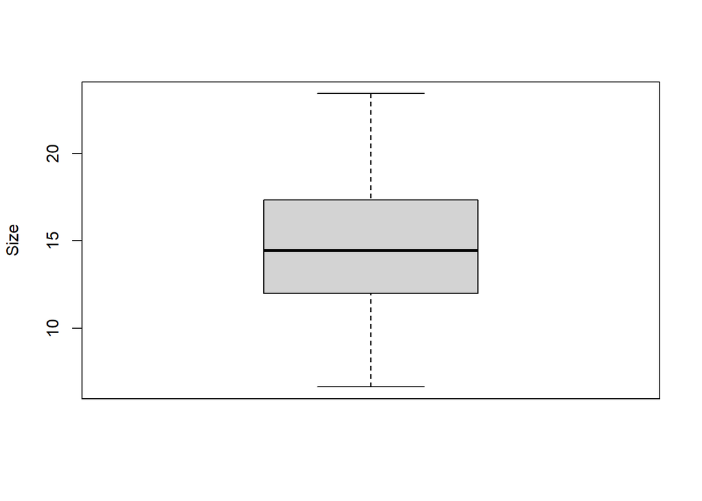

```r
boxplot(crab$size, range=1.5, ylab="Size")
```

```r
crab2 <- stack(crab)
```

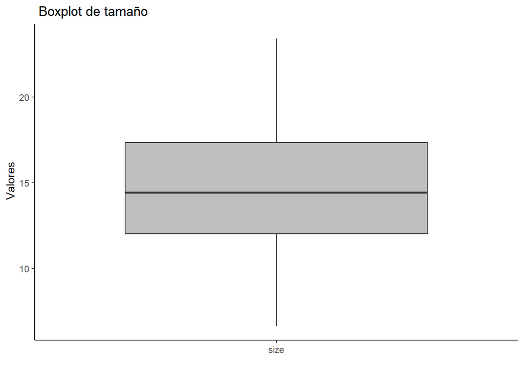

```r
filter(crab2, ind == "size") %>% #selecciono variable que me importa
  ggplot(aes(x= ind, y= values))+ # Creo la capa de datos
  geom_boxplot(outlier.color = "red", #color de outlier
               fill= "gray")+ # color de la caja
#  geom_text(aes(label= values), position = position_dodge2(0.3))+
  labs(title = " Boxplot de tamaño",
       y= " Valores",
       x= "")+
  theme_classic()
```

Una buena regla de dedo para identificar datos atípicos es: que los puntos que caen mas allá del 3er+1.5*(intercuartil) o mas bajo que 1er-1.5*(intercuartil) son valores atípicos.

#### Ejemplo:

```r
iqsize <- 17.34-12.02
atip_inf <-(12.02-(iqsize*1.5))
atip_inf
```

```
[1] 4.04
```

```r
atip_sup <- (17.34+(iqsize*1.5))
atip_sup
```

```
[1] 25.32
```

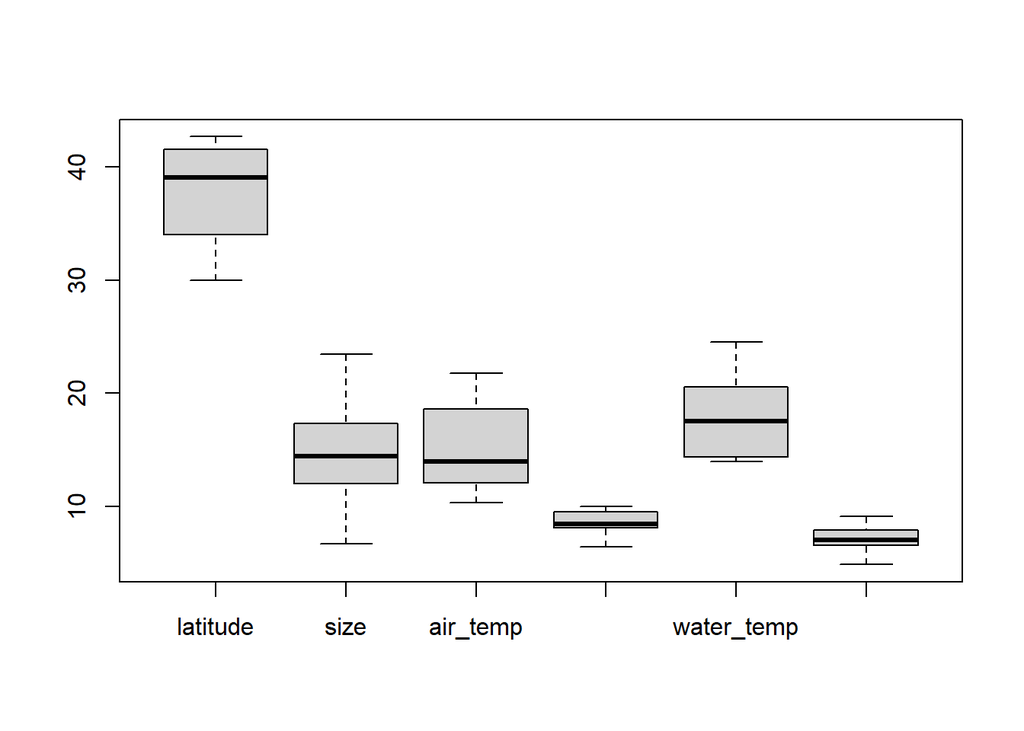

```r
boxplot(crab)
```

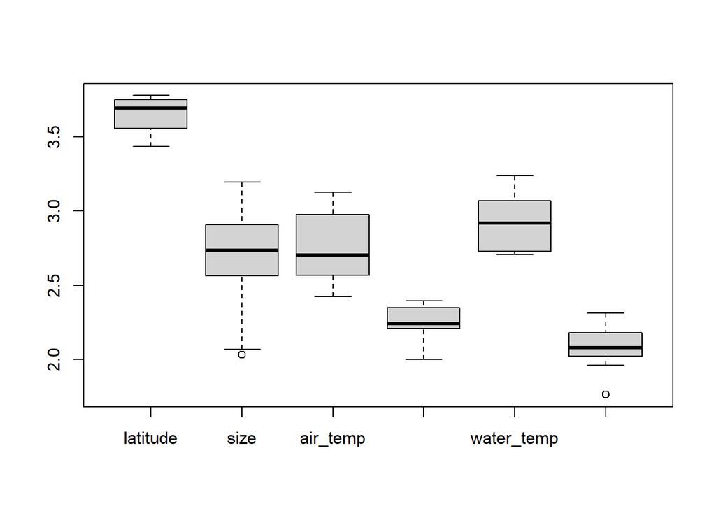

```r
boxplot(log(crab+1))
```

En ggplot tenemos que usar la base de datos que tenemos en formato “long”

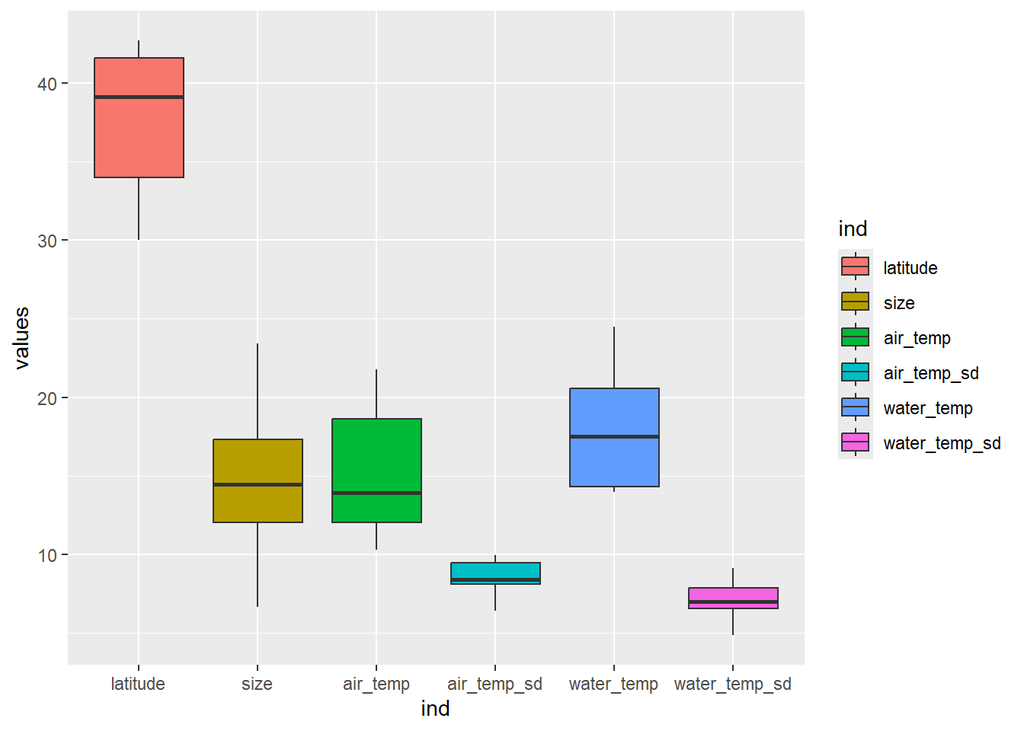

```r
 ggplot(crab2, aes(x= ind, y= values, fill= ind))+ # Creo la capa de datos
  geom_boxplot(outlier.color = "red") # color outlier
```

```r
#  geom_text(aes(label= values), position = position_dodge2(0.3))+
  labs(title = " Boxplot de tamaño",
       y= " Valores",
       x= "")+
  theme_classic()#+
```

```r
 # theme(legend.position ="none") # leyendas variable
```

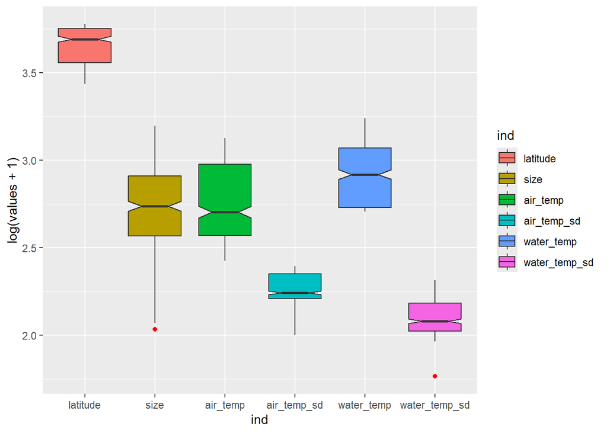

```r
ggplot(crab2, aes(x= ind, y= log(values+1), fill= ind))+ # Creo la capa de datos
  geom_boxplot(outlier.color = "red", notch = TRUE) # color outlier
```

```r
#  geom_text(aes(label= values), position = position_dodge2(0.3))+
  labs(title = " Boxplot de tamaño",
       y= " Valores",
       x= "")+
  theme_classic()#+
```

```r
 # theme(legend.position ="none") # leyendas variable
```

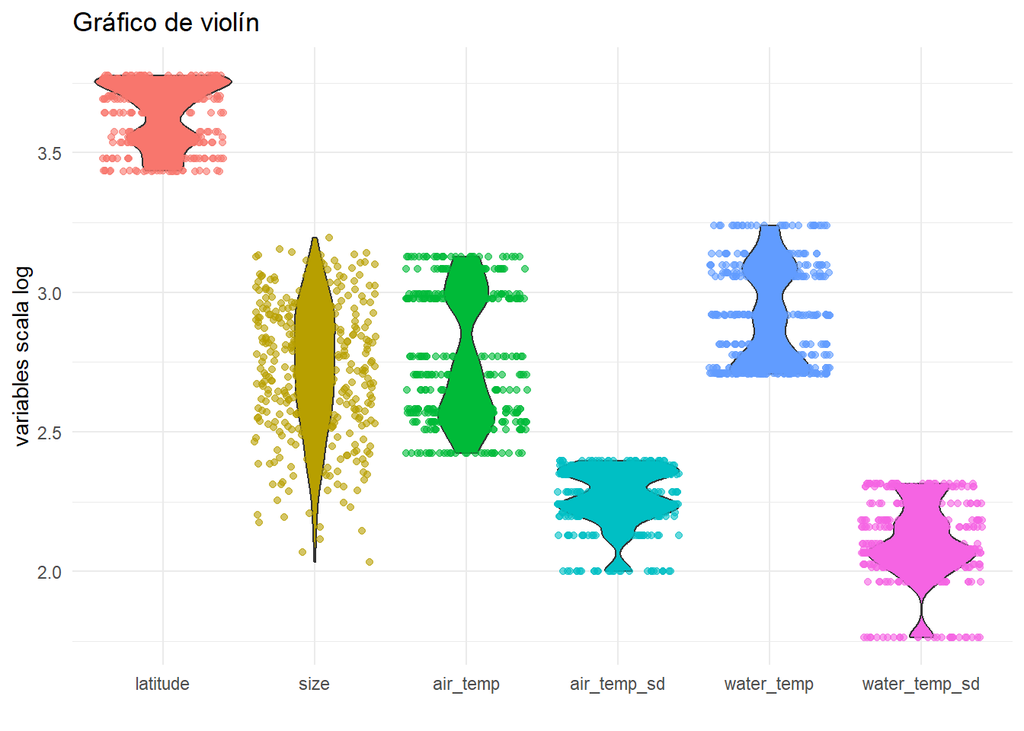

```r
ggplot(crab2, aes(x=ind, y= log(values+1), fill=ind))+
  geom_violin()+ # geometría de violin
  geom_jitter(aes(col= ind), alpha= 0.6)+
    labs(title = "Gráfico de violín",
         x= "", y= "variables scala log")+
  theme_minimal()+
  theme(legend.position = "none") #quitar leyenda de variables
```

#### Ahora en conjunto

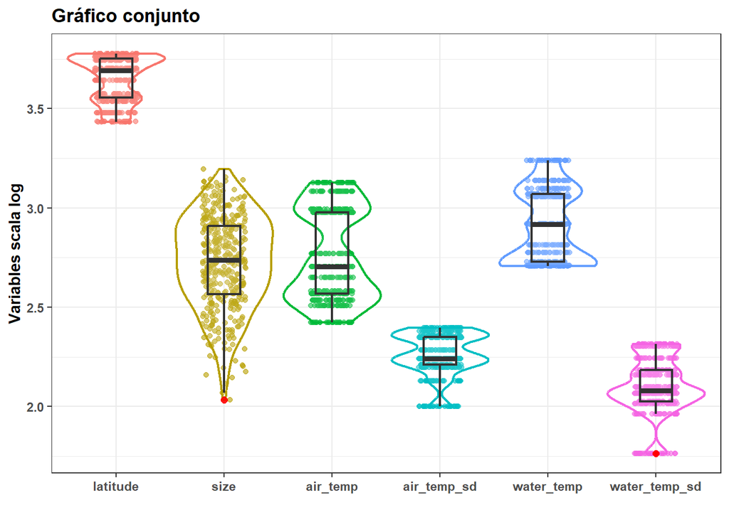

```r
ggplot(crab2, aes(x=ind, y= log(values+1)))+
  geom_jitter( aes(color=ind),width = 0.2, alpha= 0.6)+
  geom_violin(aes(color=ind),
              scale = "width",
              alpha= 0.1, # valor de opacidad
              size= 0.8)+ # tamaño de la linea
  geom_boxplot(width = 0.3, alpha= 0.1, size= 0.8,
               outlier.color = "red",
               outlier.alpha = 0.9,
               outlier.size = 2)+
  labs(title = "Gráfico conjunto",
       x= "", y= "Variables scala log")+
  theme_bw()+
  theme(legend.position = "none", # quitar leyenda de variables
       text = element_text(size= 11, face = "bold")) # Ajustar tamaño de texto
```

## Dotplots

#### Con base R

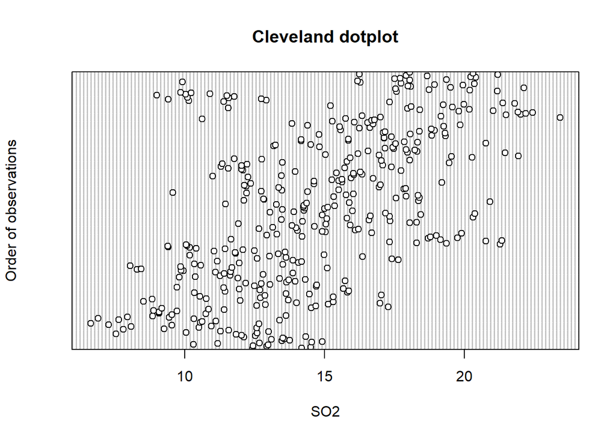

```r
dotchart(crab$size,
         ylab = "Order of observations",
         xlab = "SO2",
         main = "Cleveland dotplot")
```

#### Modo ggplot

```r
d_plot <-  crab %>%
   mutate(index = seq(n())) %>%
  select_if(is.numeric) %>%
  pivot_longer(cols = !index,
               names_to = "Variable",
               values_to = "Value") %>%
  ggplot(aes(x= Value, y= index, col= Variable))+
  geom_point(size= 2, alpha=0.6)+
  scale_color_viridis_d(option = "mako",
                        begin = 0.1,
                        end = 0.8)+
  facet_wrap(~Variable, scales = "free")+
  labs(y= "Order of ovservation")+
   theme_bw()+
   theme(legend.position = "none",
         text = element_text(size=10))
```

## Histogramas

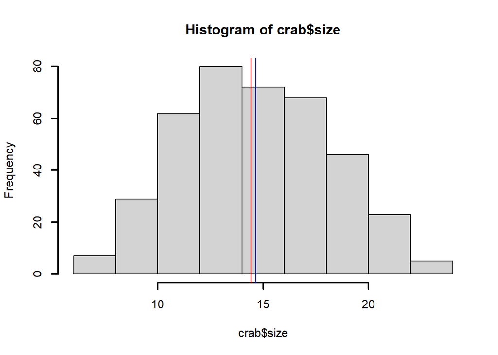

```r
hist(crab$size,lwd=2)
abline(v = 14.65, col = "blue")
abline(v = 14.435, col = "red")
```

#### Todas las variables juntas (base R)

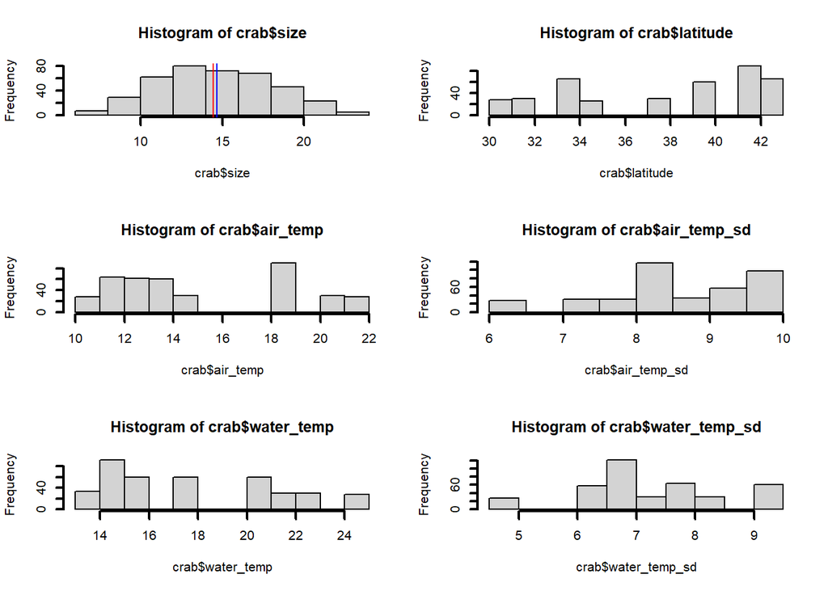

```r
par(mfrow=c(3,2))
hist(crab$size,lwd=2); abline(v = c(14.65,14.435), col = c("blue", "red"))
hist(crab$latitude,lwd=2)
hist(crab$air_temp,lwd=2)
hist(crab$air_temp_sd,lwd=2)
hist(crab$water_temp,lwd=2)
hist(crab$water_temp_sd,lwd=2)
```

#### Modo ggplot

Volvemos a emplear nuestra base `crab2` en modo largo

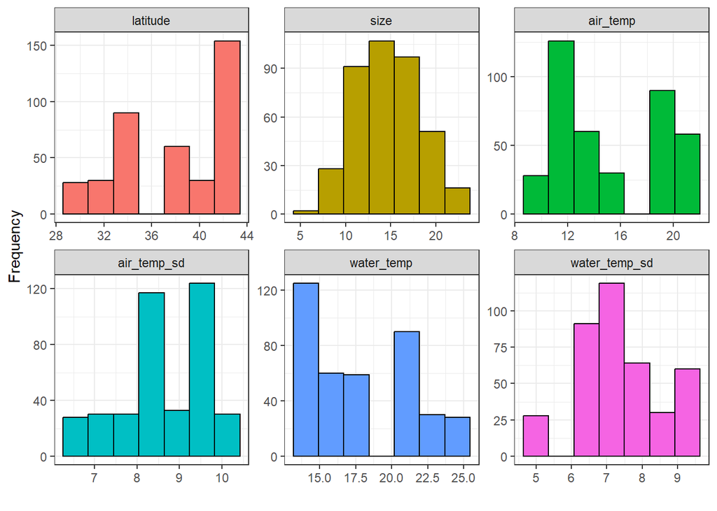

```r
ggplot(crab2, aes(x=values, fill= ind))+
  geom_histogram( bins = 7, color="black")+
  facet_wrap(.~ind, scales = "free")+ # Crear los paneles por variable
  theme_bw()+
  theme(legend.position = "none")+
  labs(x="", y= " Frequency")
```

## Gráficos de densidad

#### ggplot de una variable

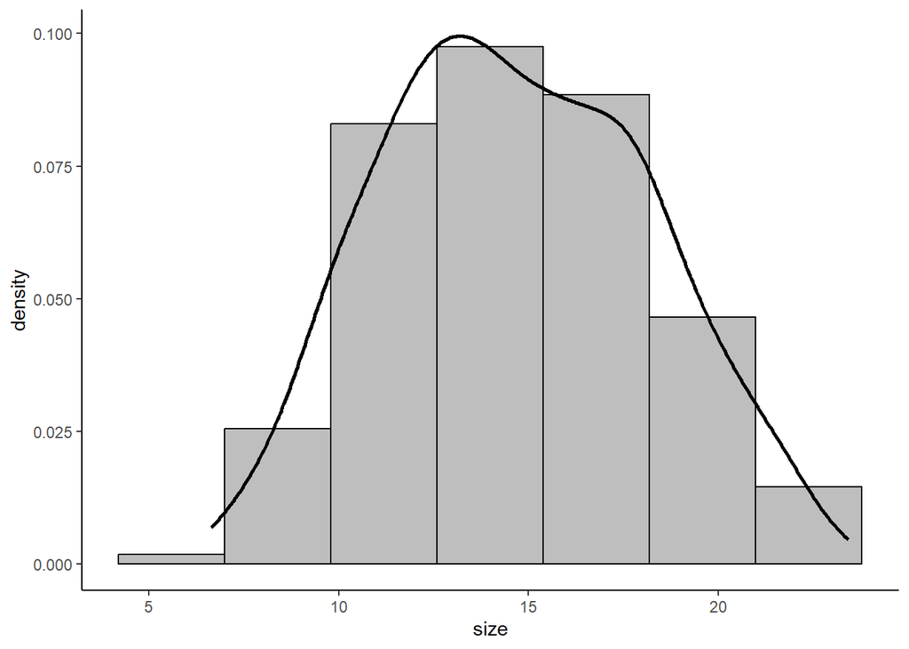

```r
ggplot(crab, aes(x= size))+
  geom_histogram(aes(y = stat(density)),
                 bins = 7,
                 fill= "gray",
                 color="black")+
  geom_density(size=1)+
  theme_classic()
```

#### ggplot de todas las variables

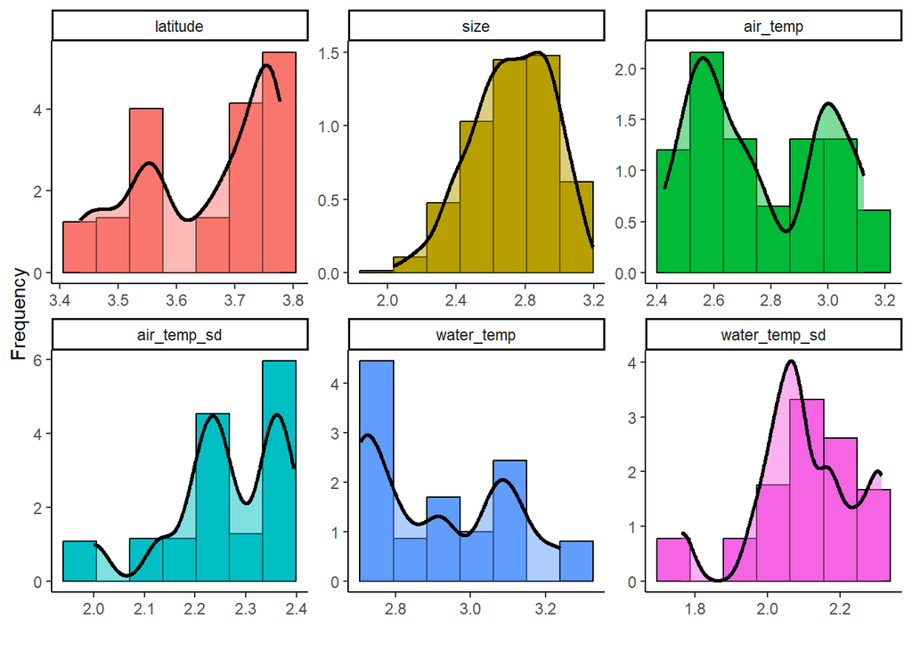

```r
ggplot(crab2, aes(x=log(values+1), fill= ind))+
  geom_histogram(aes(y = stat(density), fill= ind),
                 bins = 7, color="black")+
  geom_density(aes(fill= ind),
               size=1, alpha= 0.5)+
  facet_wrap(.~ind, scales = "free")+ # Crear los paneles por variable
  theme_classic()+
  theme(legend.position = "none")+
  labs(x="", y= " Frequency")
```

Ahora pondremos las variables a la misma escala y las exploraremos con un gráfico de olas

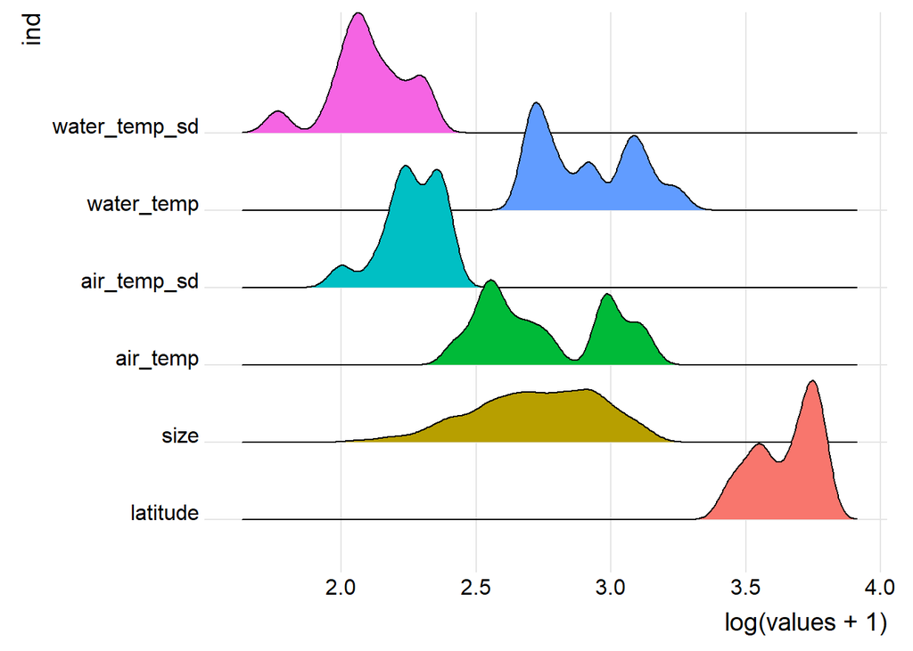

```r
ggplot(crab2, aes(x= log(values+1), y= ind, fill= ind))+
  geom_density_ridges()+
  theme_ridges() +
  theme(legend.position = "none")
```

## QQ-plots

Primero con plot base

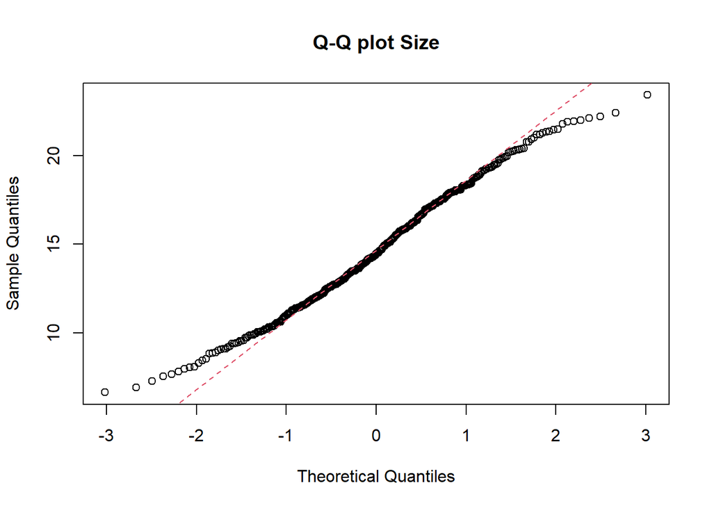

```r
qqnorm(crab$size, main="Q-Q plot Size")
qqline(crab$size, col = 2, lty = 2)
```

#### modo ggplot para QQplot

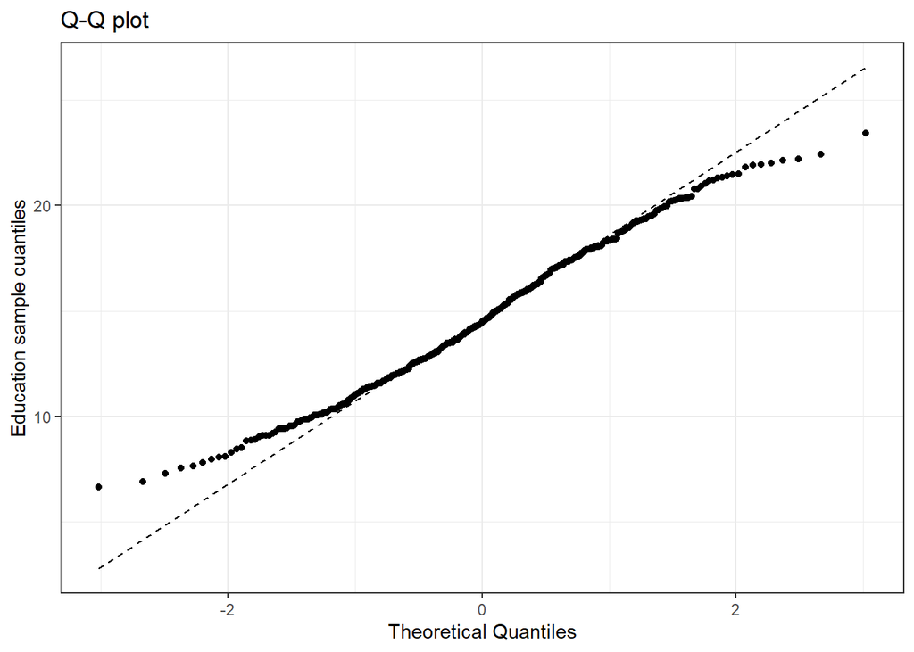

```r
ggplot(crab, aes(sample=size))+
  stat_qq()+
  stat_qq_line(linetype= "dashed")+
    labs(title = "Q-Q plot",
       x= "Theoretical Quantiles",
       y= "Education sample cuantiles")+
  theme_bw()
```

## Relaciones Bivariadas

Veamos que relación hay entre las distintas variables. Aquí utilizo una función smoooth (regresión con pesos locales) que permite sugerir con los propios datos que tipo de relación pudieran tener.

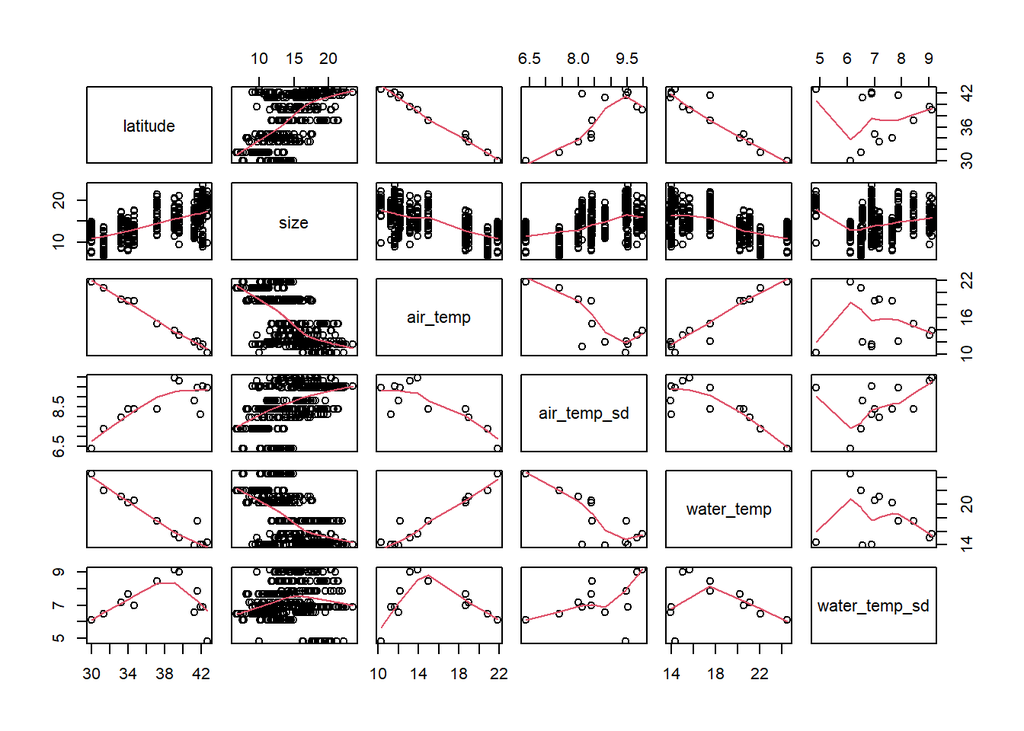

```r
pairs(crab, panel=panel.smooth)
```

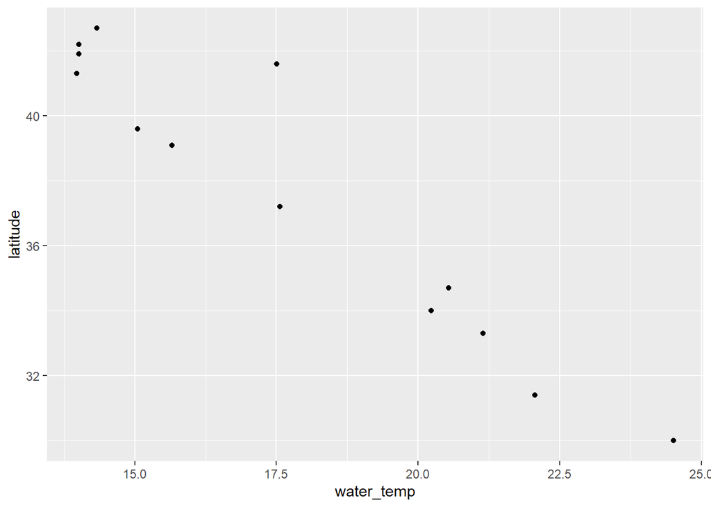

```r
ggplot(data = pie_crab, aes(y = latitude, x = water_temp)) +
  geom_point()
```

```r
crab_stats <- pie_crab %>% group_by(latitude, site) %>%
  summarise(
  n = n(),
  mean_mm = mean(size),
  min_mm = min(size),
  max_mm = max(size),
  sd_mm = sd(size),
  median_mm = median(size)
  )
```

```r
crab_stats
```

```
# A tibble: 13 × 8
# Groups:   latitude [13]
   latitude site      n mean_mm min_mm max_mm sd_mm median_mm
      <dbl> <chr> <int>   <dbl>  <dbl>  <dbl> <dbl>     <dbl>
 1     30   GTM      28   12.4    7.55   14.9  1.80     12.6
 2     31.4 SI       30    9.85   6.64   13.6  1.79      9.55
 3     33.3 NIB      30   13.3    8.52   17.3  2.42     13.3
 4     34   ZI       35   12.1    8.05   15.7  2.01     12.0
 5     34.7 RC       25   12.5    9.4    17.6  2.34     12.1
 6     37.2 VCR      30   16.3   11.7    21.4  2.94     16.0
 7     39.1 DB       30   15.6   11.5    20.4  2.12     15.1
 8     39.6 JC       30   15.3    9.58   20.9  2.72     15.4
 9     41.3 CT       33   14.7   11.0    19.5  2.36     15.5
10     41.6 NB       29   17.1   13.2    21.9  2.29     17.2
11     41.9 CC       27   16.8   10.6    19.8  2.05     16.7
12     42.2 BC       37   16.2    9.01   23.4  4.81     17.3
13     42.7 PIE      28   18.5    9.92   22.1  2.30     18.4
```

Aquí, creamos un boxplot del tamaño del caparazón del cangrejo (mm) por latitud. En general, el tamaño de los cangrejos aumenta hacia latitudes más altas, siguiendo la regla de Bergmann.

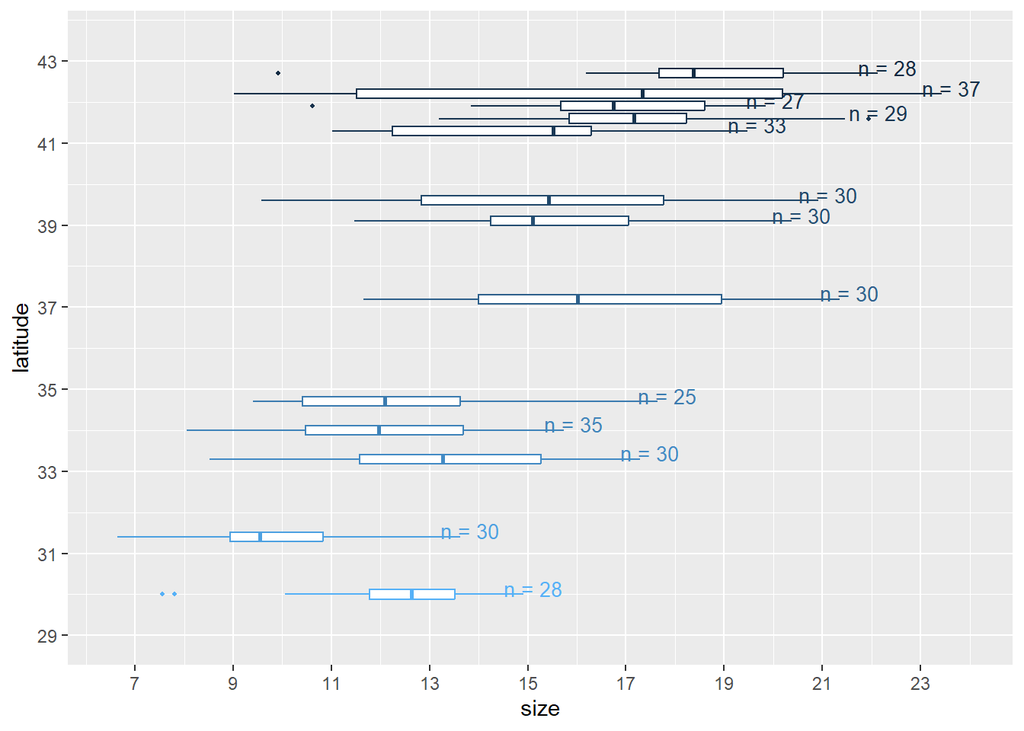

```r
pie_crab %>%
  ggplot(aes(y=latitude)) +
  geom_boxplot(aes(size, group = latitude, color=-latitude), outlier.size=0.8) +
  geom_text(data = crab_stats,
            aes(label = (paste('n =', n)),
                group = latitude,
                color = -latitude,
                x= max_mm + 0.2,
                y= latitude + 0.15),
            size=3.5) +
  scale_x_continuous(breaks = seq(from = 7, to = 23, by = 2), limits = c(6.5,24))+
  scale_y_continuous(breaks = seq(from = 29, to = 43, by = 2), limits = c(29, 43.5)) +
  theme(legend.position= "none")
```

```r
crab_summary <- pie_crab %>% group_by(site, latitude) %>%
  summarise(
    mean_size = mean(size)
    ) %>% ungroup()
```

A continuación se muestra otro gráfico del tamaño del caparazón (mm) según la latitud del lugar, con los tamaños medios registrados para cada lugar mostrados como puntos morados (todas las observaciones incluidas como puntos gris claro), lo que revela una relación aproximadamente lineal entre el tamaño medio del caparazón y la latitud.

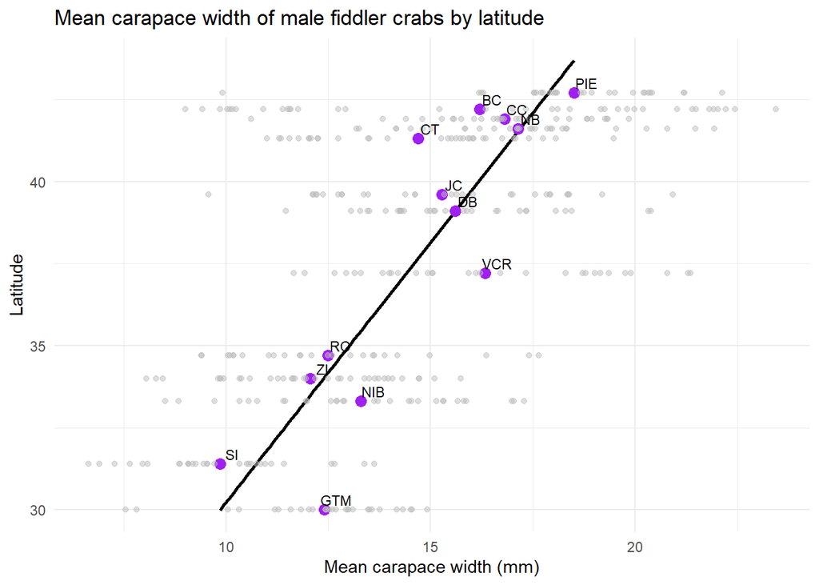

```r
ggplot(data = crab_summary, aes(y = latitude, x = mean_size)) +
  geom_point() +
  geom_smooth(method = "lm", se = FALSE, color="black") +
  geom_point(color = "purple", size=3) +
  geom_point(aes(x = size, y = latitude), data = pie_crab, color = "gray", alpha = 0.5) +
  geom_text(aes(label = site), nudge_x = 0.3, nudge_y = 0.3, size=3) +
  labs(y = "Latitude",
       x = "Mean carapace width (mm)",
       title = "Mean carapace width of male fiddler crabs by latitude") +
  theme_minimal()
```